# Improving the Models

Krushang Shah & Rajiv Basnet

6/24/2020

```r
library(tidyverse)
library(modelr)
library(plotly)
library(gtrendsR)
library(caret)
```

#Attempt to improve the models

## Import most recent data

Check and work with the data from 2004 to present:

```r
data <- read.csv("merged_present.csv")
data <- data %>% mutate(sales = log(sales), Period = as.Date(Period,"%m/%d/%Y"))
head(data)
```

|  | Period | sales | suvs | insurance |
| --- | --- | --- | --- | --- |
| 1 | 2004-01-01 | 11.02102 | 94 | 92 |
| 2 | 2004-02-01 | 11.08567 | 91 | 84 |
| 3 | 2004-03-01 | 11.27292 | 88 | 86 |
| 4 | 2004-04-01 | 11.20166 | 94 | 87 |
| 5 | 2004-05-01 | 11.25792 | 93 | 86 |
| 6 | 2004-06-01 | 11.22997 | 93 | 95 |

## Check and plot most recent data

```r
#using models defined in the paper to check how well it works with data from 2011 to present
all_data <- data %>%
  rename(actual = sales) %>%
  mutate(baseline = NA, trends = NA) %>%
  mutate(lag1 = lag(actual, 1), lag12 = lag(actual, 12))

K <- 17
num_rows <- nrow(all_data)
for (k in K: (num_rows -1) ) {
  model1 <- lm(actual ~ lag1 + lag12, data = all_data[1:k, ])
  model2 <- lm(actual ~ lag1 + lag12 + suvs + insurance, data = all_data[1:k, ])
  all_data$baseline[k + 1] <- predict(model1, all_data[k + 1,])
  all_data$trends[k + 1] <- predict(model2, all_data[k + 1,])
}

mae_baseline <- sum(abs(all_data$actual - all_data$baseline), na.rm = TRUE)/(num_rows - 17)
mae_trends <- sum(abs(all_data$actual - all_data$trends), na.rm = TRUE)/(num_rows - 17)

mae_baseline
```

```
## [1] 0.05615793
```

```r
mae_trends
```

```
## [1] 0.0625183
```

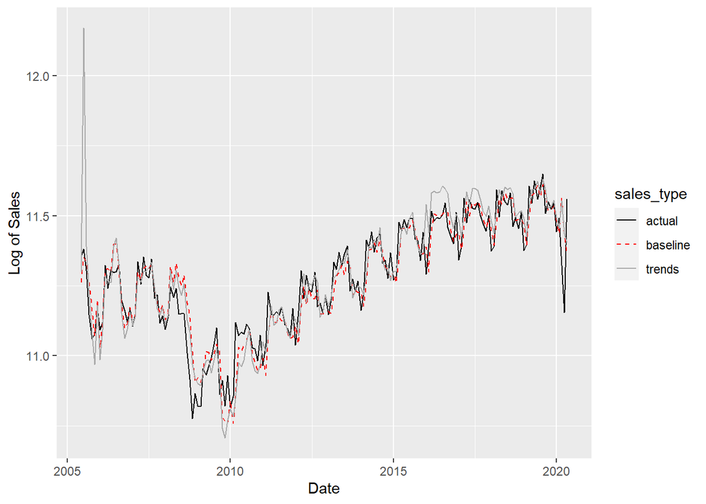

```r
all_data[18:num_rows, ] %>%
  pivot_longer(c("actual", "baseline", "trends"), names_to = "sales_type", values_to = "num_of_sales") %>%
  ggplot(aes(x = Period, y = num_of_sales, group = sales_type, color = sales_type)) +
  geom_line(aes(y = num_of_sales, color = sales_type, linetype= sales_type)) +
  scale_color_manual(values=c("black", "red", "darkgray")) +
  scale_linetype_manual(values=c("solid", "dashed", "solid")) +
  labs(x = "Date", y = "Log of Sales")
```

=> There is a significant drop in the actual sales in 2020 (Reason: COVID-19)

However, even adding the Google Trends data did not actually make an improvement for the prediction in this time.

Could the prediction with both Baseline and Google Trends data are more influenced by lag(sales, 12)?

Here, we will be using lag(sales, 1) and lag(sales, 2) in order to check how well the models would fit the data.

## Model Improvement

```r
all_data <- data %>%
  rename(actual = sales) %>%
  mutate(baseline = NA, trends = NA) %>%
  mutate(lag1 = lag(actual, 1), lag2 = lag(actual, 2), lag12 = lag(actual, 12))

K <- 17
num_rows <- nrow(all_data)
for (k in K: (num_rows -1) ) {
  model1 <- lm(actual ~ lag1 + lag2, data = all_data[1:k, ])
  model2 <- lm(actual ~ lag1 + lag2 + suvs + insurance, data = all_data[1:k, ])
  all_data$baseline[k + 1] <- predict(model1, all_data[k + 1,])
  all_data$trends[k + 1] <- predict(model2, all_data[k + 1,])
}

mae_baseline <- sum(abs(all_data$actual - all_data$baseline), na.rm = TRUE)/(num_rows - 17)
mae_trends <- sum(abs(all_data$actual - all_data$trends), na.rm = TRUE)/(num_rows - 17)

mae_baseline
```

```
## [1] 0.06614693
```

```r
mae_trends
```

```
## [1] 0.06579673
```

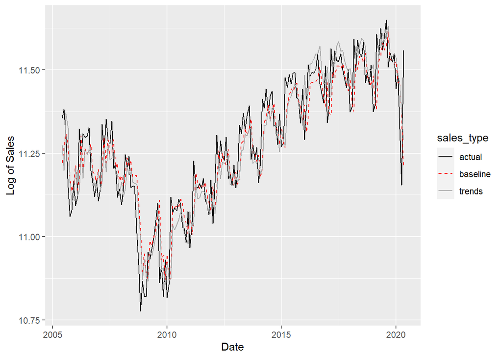

```r
all_data[18:num_rows, ] %>%
  pivot_longer(c("actual", "baseline", "trends"), names_to = "sales_type", values_to = "num_of_sales") %>%
  ggplot(aes(x = Period, y = num_of_sales, group = sales_type, color = sales_type)) +
  geom_line(aes(y = num_of_sales, color = sales_type, linetype= sales_type)) +
  scale_color_manual(values=c("black", "red", "darkgray")) +
  scale_linetype_manual(values=c("solid", "dashed", "solid")) +
  labs(x = "Date", y = "Log of Sales")
```

=> It appears that using lag last two months in order to predict the data kind of fits the graph well. But, the mean absolute error increased.

Bias-Variance Trade Off?

The function that we use for the model in order to make approximation looks good. However, the MAE is compromised.

What improvements could be made to the models without having to use additional data?

=> Would the models perform better if we were to use lags though (1:n months) with lag(sales, 12 months)?

Let’s check it with author’s data first.

## Import Author’s Data

```r
author_data <- read.csv("merged_author.csv")
author_data <- author_data %>% mutate(sales = log(sales), Period = as.Date(Period))
head(author_data)
```

|  | Period | sales | suvs | insurance |
| --- | --- | --- | --- | --- |
| 1 | 2004-01-01 | 11.02332 | 0.00 | 0.00 |
| 2 | 2004-02-01 | 11.08799 | -0.12 | -0.01 |
| 3 | 2004-03-01 | 11.27521 | -0.05 | -0.09 |
| 4 | 2004-04-01 | 11.20398 | -0.12 | -0.08 |
| 5 | 2004-05-01 | 11.26012 | -0.07 | -0.07 |
| 6 | 2004-06-01 | 11.23210 | -0.12 | 0.01 |

## Check performance on Author’s Data with a lag of (1 through 5 months)

```r
# checking model performances using data of (1 through 5) months before.

mae_baseline <-c()
mae_trends <- c()

all_data <- author_data %>%
  rename(actual = sales) %>%
  mutate(baseline = NA, trends = NA) %>%
  mutate(lag12 = lag(actual, 12))

num_rows <- nrow(all_data)
num_lags <- 1:5

a <- c()

for (n in num_lags) {
  x <- rep(NA, num_rows)
  all_data <- cbind(all_data, x)
  m <- paste("lag", as.character(n), sep = "")
  names(all_data)[names(all_data) == "x"] <- m
  all_data <- all_data %>%
    mutate(!!m := lag(actual, n))

  K <- 17

  outcome <- "actual"

  variables_mod1 <- all_data %>% select(-c(Period, baseline, trends, actual, suvs, insurance)) %>% names()

  variables_mod2 <- all_data %>% select(-c(Period, baseline, trends, actual)) %>% names()

  f1 <- as.formula(paste(outcome, paste(variables_mod1, collapse = " + "), sep = " ~ "))

  f2 <- as.formula(paste(outcome, paste(variables_mod2, collapse = " + "), sep = " ~ "))

  for (k in K: (num_rows - 1) ) {
    # get model1 : baseline
    model1 <- lm( formula = f1, data = all_data[1:k, ])

    #get  model2 : with trends
    model2 <- lm(formula = f2,  data = all_data[1:k, ])

    all_data$baseline[k + 1] <- predict(model1, all_data[k + 1,])
    all_data$trends[k + 1] <- predict(model2, all_data[k + 1,])
  }

  mae_baseline[n] <- sum(abs(all_data$actual - all_data$baseline), na.rm = TRUE)/(num_rows - K)
  mae_trends[n] <- sum(abs(all_data$actual - all_data$trends), na.rm = TRUE)/(num_rows - K)
}
```

```r
plot_mae <- data.frame(num_lags, mae_baseline, mae_trends)
plot_mae
```

| num_lags | mae_baseline | mae_trends |
| --- | --- | --- |
| 1 | 0.06343984 | 0.05667658 |
| 2 | 0.06446639 | 0.05609642 |
| 3 | 0.06622743 | 0.06090449 |
| 4 | 0.06835518 | 0.05914277 |
| 5 | 0.07102494 | 0.06082062 |

## Plot MAE (Author’s Data)

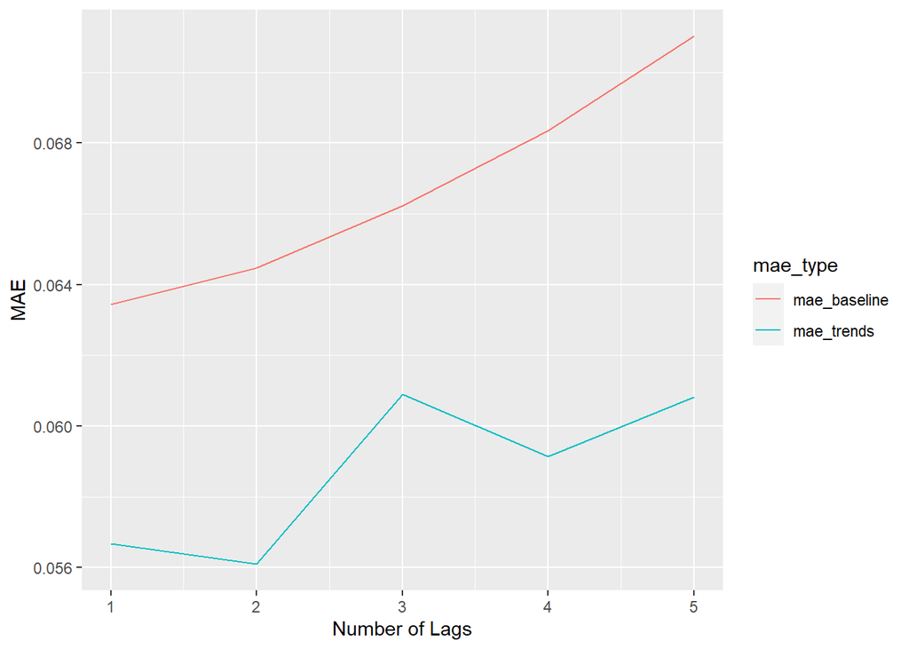

```r
plot_mae <- plot_mae %>%
  pivot_longer(c(-num_lags), names_to = "mae_type", values_to = "mae")

ggplot(plot_mae, aes(x = num_lags, y = mae, color = mae_type)) +
  geom_line() +
  labs(x = "Number of Lags", y = "MAE")
```

=> Without having to add other data, it can be seen that adding lag(actual, 2) does a slight on the model with Google Trends data, however the MAE on the baseline model does not seem to improve.

Let’s check it again with the new data from 2004 to present.

## Check performance on most recent data with a lag of (1 through 5 months)

```r
mae_baseline <-c()
mae_trends <- c()

all_data <- data %>%
  rename(actual = sales) %>%
  mutate(baseline = NA, trends = NA) %>%
  mutate(lag12 = lag(actual, 12))

num_rows <- nrow(all_data)
num_lags <- 1:5

a <- c()

for (n in num_lags) {
  x <- rep(NA, num_rows)
  all_data <- cbind(all_data, x)
  m <- paste("lag", as.character(n), sep = "")
  names(all_data)[names(all_data) == "x"] <- m
  all_data <- all_data %>%
    mutate(!!m := lag(actual, n))

  K <- 17

  outcome <- "actual"

  variables_mod1 <- all_data %>% select(-c(Period, baseline, trends, actual, suvs, insurance)) %>% names()

  variables_mod2 <- all_data %>% select(-c(Period, baseline, trends, actual)) %>% names()

  f1 <- as.formula(paste(outcome, paste(variables_mod1, collapse = " + "), sep = " ~ "))

  f2 <- as.formula(paste(outcome, paste(variables_mod2, collapse = " + "), sep = " ~ "))

  for (k in K: (num_rows - 1) ) {
    # get model1 : baseline
    model1 <- lm( formula = f1, data = all_data[1:k, ])

    #get  model2 : with trends
    model2 <- lm(formula = f2,  data = all_data[1:k, ])

    all_data$baseline[k + 1] <- predict(model1, all_data[k + 1,])
    all_data$trends[k + 1] <- predict(model2, all_data[k + 1,])
  }

  mae_baseline[n] <- sum(abs(all_data$actual - all_data$baseline), na.rm = TRUE)/(num_rows - K)
  mae_trends[n] <- sum(abs(all_data$actual - all_data$trends), na.rm = TRUE)/(num_rows - K)
}
```

```r
plot_mae <- data.frame(num_lags, mae_baseline, mae_trends)

plot_mae
```

| num_lags | mae_baseline | mae_trends |
| --- | --- | --- |
| 1 | 0.05615793 | 0.06251830 |
| 2 | 0.05488661 | 0.06210174 |
| 3 | 0.05575427 | 0.06766681 |
| 4 | 0.05701370 | 0.07066002 |
| 5 | 0.05822464 | 0.07151247 |

## Plot MAE (Most Recent Data)

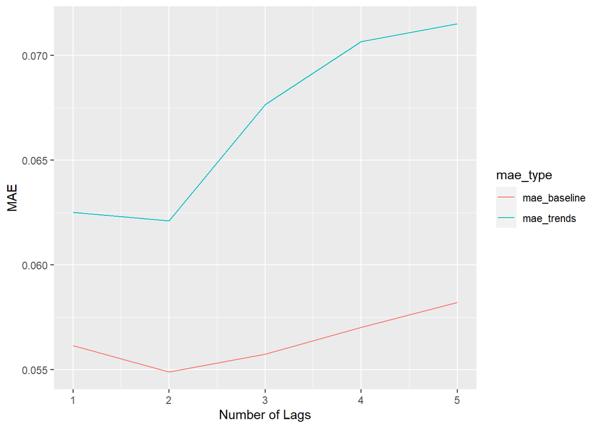

```r
plot_mae <- plot_mae %>%
  pivot_longer(c(-num_lags), names_to = "mae_type", values_to = "mae")

ggplot(plot_mae, aes(x = num_lags, y = mae, color = mae_type)) +
  geom_line() +
  labs(x = "Number of Lags", y = "MAE")
```

=> Overall, on the recent data we can see that including a lag of 2 months makes an improvement to the MAE on both the models.

Better Models?

Baseline: y(t) = y(t-1) + y(t-2) + y(t-12) AND With Trends: y(t) = y(t-1) + y(t-2) + y(t-12) + suvs + insurance

However, unlike the paper claims, (with a rolling window on 2004 to present), MAE with trends is greater than that of MAE baseline.

Possible Cause: The time-frame from 2004 to present is pretty long.

That raises a whole new question again.

Would a moving window work better than the rolling window?